# Scales in ggplot2

2024

## load the ggplot2 package

```r
library(ggplot2)
```

## Overview of scales

- **Color and Fill**: For mapping numeric data to gradients of colors.
  - `scale_color_gradient()`, `scale_fill_gradient()`: Gradient (two colors).
  - `scale_color_gradient2()`, `scale_fill_gradient2()`: Diverging gradient (three colors).
  - `scale_color_gradientn()`, `scale_fill_gradientn()`: Gradient of n colors.
- **Position**: For continuous position scales (x and y axes).
  - `scale_x_continuous()`, `scale_y_continuous()`: Default continuous position scales.
  - `scale_x_log10()`, `scale_y_log10()`: Logarithmic scales.
  - `scale_x_sqrt()`, `scale_y_sqrt()`: Square root scales.
  - `scale_x_reverse()`, `scale_y_reverse()`: Reverse scales.
- **Color and Fill**: For mapping discrete variables to colors.
  - `scale_color_hue()`, `scale_fill_hue()`: Default discrete color scale.
  - `scale_color_brewer()`, `scale_fill_brewer()`: Color scales from the ColorBrewer palettes.
  - `scale_color_manual()`, `scale_fill_manual()`: Manual color scales to specify custom colors.
  - `scale_color_viridis_d()`, `scale_fill_viridis_d()`: Discrete scales using the viridis color palette.
- **Shape**: For mapping discrete variables to shapes.
  - `scale_shape()`: Default shape scale.
  - `scale_shape_manual()`: Manual shape scales to specify custom shapes.
- **Position**: For date and datetime data.
  - `scale_x_date()`, `scale_y_date()`: Date scales for the x or y axis.
  - `scale_x_datetime()`, `scale_y_datetime()`: DateTime scales for the x or y axis.
  - `scale_x_time()`, `scale_y_time()`: Time scales (without dates).
- **Size**: For mapping variables to sizes.
  - `scale_size()`: Continuous data to size.
  - `scale_size_manual()`: Manual size mapping.
  - `scale_size_area()`: Proportional area scales.
- **Alpha**: For mapping variables to transparency levels.
  - `scale_alpha()`: Continuous data to alpha (transparency).
  - `scale_alpha_manual()`: Manual alpha scales.

## Continuous Scales: Color Gradient

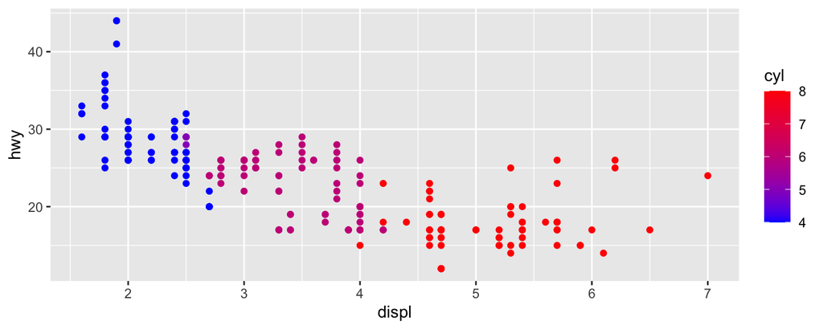

```r
# Use `scale_color_gradient()` to map numeric data to a two-color gradient.
library(ggplot2)
ggplot(mpg, aes(x = displ, y = hwy, color = cyl)) +
  geom_point() +
  scale_color_gradient(low = "blue", high = "red")
```

## Continuous Scales: Logarithmic Transformation

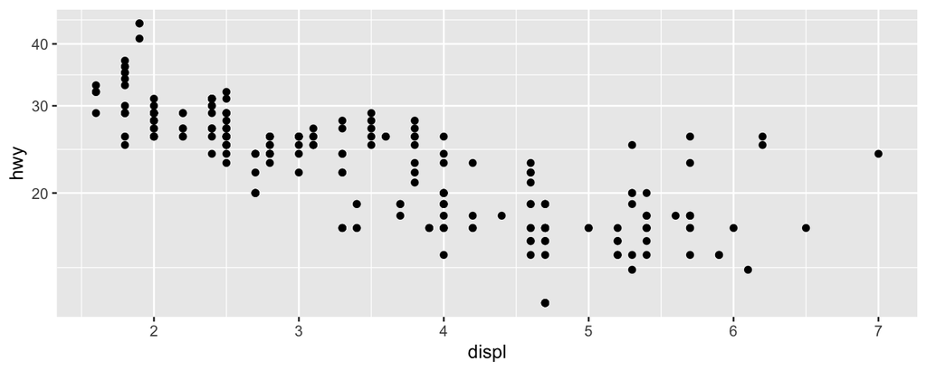

```r
# Apply a logarithmic transformation to an axis with `scale_y_log10()`.
ggplot(mpg, aes(x = displ, y = hwy)) +
  geom_point() +
  scale_y_log10()
```

## Discrete Scales: Color Brewer

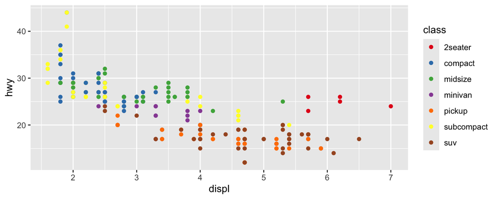

```r
# Use `scale_color_brewer()` for discrete variables, utilizing ColorBrewer palettes.
ggplot(mpg, aes(x = displ, y = hwy, color = class)) +
  geom_point() +
  scale_color_brewer(palette = "Set1")
```

## Discrete Scales: Manual Color

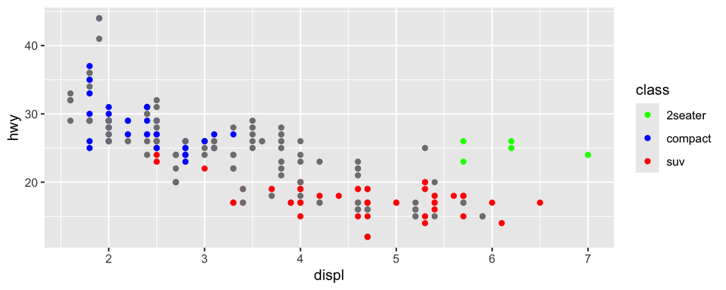

```r
# Manually set colors for discrete variables with `scale_color_manual()`.
ggplot(mpg, aes(x = displ, y = hwy, color = class)) +
  geom_point() +
  scale_color_manual(values = c("compact" = "blue", "suv" =
                                "red", "2seater" = "green"))
```